# Assignment 2

Author

Nathan Weitershausen

```r
library(dplyr)
library(ggplot2)
library(nycflights13)
airlines <- airlines
airports <- airports
flights <- flights
planes <- planes
weather <- weather
```

# Question 1

Find the top 10 most popular destinations in the flights data. How many flights went to each?

```r
Top10Flights <- sort(table(flights$dest), decreasing = TRUE)

Top10Flights <- head(Top10Flights, 10)

Top10Flights
```

```
  ORD   ATL   LAX   BOS   MCO   CLT   SFO   FLL   MIA   DCA
17283 17215 16174 15508 14082 14064 13331 12055 11728  9705
```

## Summary

The 10 most popular destinations in the flights data, in order from most to least popular and with the number of flights in parentheses, are: ORD (17,283), ATL (17,215), LAX (16,174), BOS (15,508), MCO (14082), CLT (14,064), SFO (13,331), FLL (12,055), MIA (11,728), and DCA (9705).

# Question 2

Create two new categorical variables in flights based on the departure time (dep_time), and arrival time (arr_time). These new variables should have four categories: “early morning” for 12am to 6am, “morning” for 6am to 12pm, “afternoon” for 12pm to 6pm, and “evening” for 6pm to 12am. Show barplots of both of these new variables. What percentage of flights were “red eye” flights? We’ll define these as flights that depart in “afternoon” or “evening” and arrive in “early morning” or “morning.”

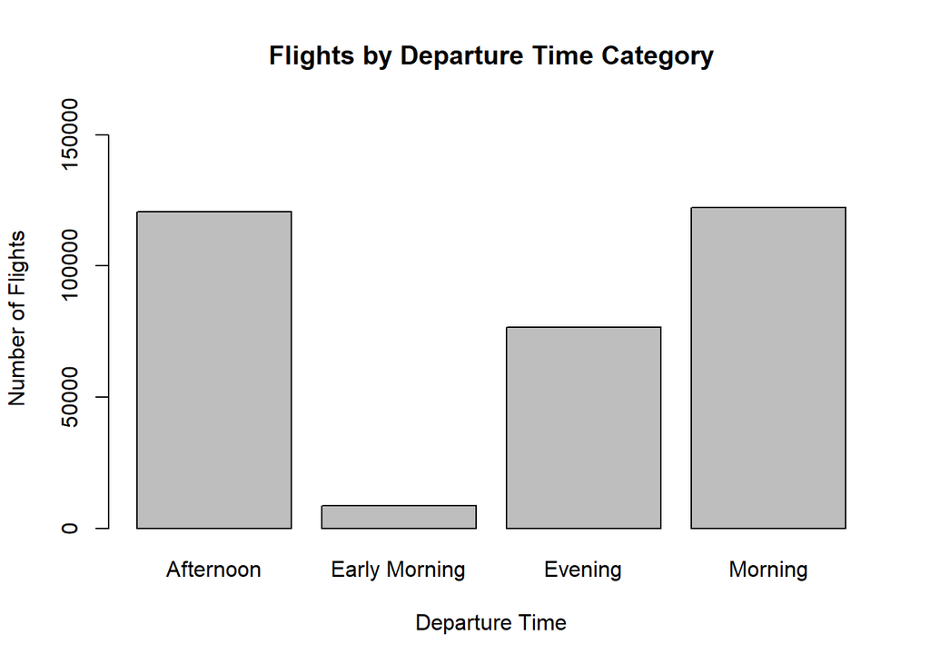

```r
flights$dep_time_category <- ifelse(is.na(flights$dep_time), NA, ifelse(flights$dep_time < 600, "Early Morning", ifelse(flights$dep_time < 1200, "Morning", ifelse(flights$dep_time < 1800, "Afternoon", "Evening"))))

flights$arr_time_category <- ifelse(is.na(flights$arr_time), NA, ifelse(flights$arr_time < 600, "Early Morning", ifelse(flights$arr_time < 1200, "Morning", ifelse(flights$arr_time < 1800, "Afternoon", "Evening"))))

Time_Labels <- c("Early Morning", "Morning", "Afternoon", "Evening")

barplot(table(flights$dep_time_category), main = "Flights by Departure Time Category", xlab = "Departure Time", ylab = "Number of Flights", ylim = c(0, 160000))
```

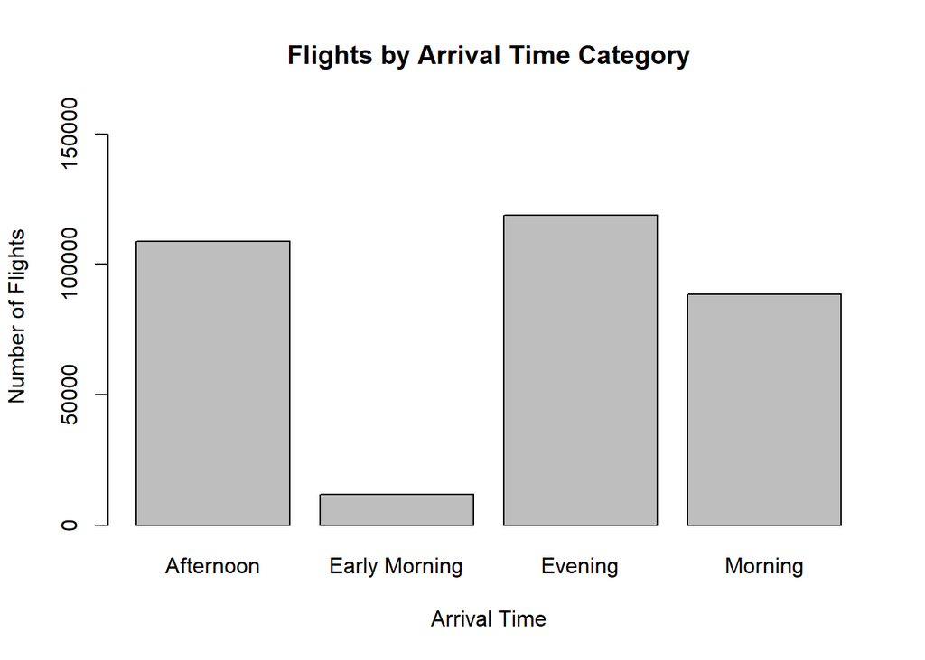

```r
barplot(table(flights$arr_time_category), main = "Flights by Arrival Time Category", xlab = "Arrival Time", ylab = "Number of Flights", ylim = c(0, 160000))
```

```r
# Percentage of Flights that were Red Eye Flights (Depart: Afternoon and Evening, Arrive: Early Morning and Morning)

flights <- flights[!is.na(flights$dep_time) & !is.na(flights$arr_time),]
flights$red_eye <- flights$dep_time_category %in% c("Afternoon", "Evening") & flights$arr_time_category %in% c("Early Morning", "Morning")

RedEyePercentage <- mean(flights$red_eye, na.rm = TRUE) * 100

RedEyeNumber <- table(flights$red_eye)

RedEyePercentage <- data.frame(Red_Eye = names(RedEyeNumber), Amount = as.vector(RedEyeNumber), Percentage = as.vector(prop.table(RedEyeNumber)*100))

RedEyePercentage
```

```
  Red_Eye Amount Percentage
1   FALSE 317430  96.758854
2    TRUE  10633   3.241146
```

## Summary

About 3.24% (10,633) of flights were Red Eye Flights.

# Question 3

Were there any planes that flew for multiple airlines? If so, how many were there and which airlines did they fly for?

```r
Plane_Airlines_Carriers <- unique(flights[c("tailnum", "carrier")])
Carriers_by_Tailnum <- split(Plane_Airlines_Carriers$carrier, Plane_Airlines_Carriers$tailnum)
Carriers_by_Tailnum <- Carriers_by_Tailnum[sapply(Carriers_by_Tailnum, length) >1]
as.data.frame(Carriers_by_Tailnum)
```

```
  N146PQ N153PQ N176PQ N181PQ N197PQ N200PQ N228PQ N232PQ N933AT N935AT N977AT
1     9E     9E     9E     9E     9E     9E     9E     9E     FL     FL     FL
2     EV     EV     EV     EV     EV     EV     EV     EV     DL     DL     DL
  N978AT N979AT N981AT N989AT N990AT N994AT
1     FL     FL     FL     FL     FL     FL
2     DL     DL     DL     DL     DL     DL
```

## Summary

There were 17 planes that flew for multiple airlines. Planes N146PQ, N153PQ, N176PQ, N181PQ, N197PQ, N200PQ, N228PQ, and N232PQ flew for airlines 9E and EV. Planes N933AT, N935AT, N977AT, N978AT, N979AT, N981AT, N989AT, N990AT, and N994AT flew for airlines FL and DL.

# Question 4

```r
weather
```

```
# A tibble: 26,115 × 15
   origin  year month   day  hour  temp  dewp humid wind_dir wind_speed
   <chr>  <int> <int> <int> <int> <dbl> <dbl> <dbl>    <dbl>      <dbl>
 1 EWR     2013     1     1     1  39.0  26.1  59.4      270      10.4
 2 EWR     2013     1     1     2  39.0  27.0  61.6      250       8.06
 3 EWR     2013     1     1     3  39.0  28.0  64.4      240      11.5
 4 EWR     2013     1     1     4  39.9  28.0  62.2      250      12.7
 5 EWR     2013     1     1     5  39.0  28.0  64.4      260      12.7
 6 EWR     2013     1     1     6  37.9  28.0  67.2      240      11.5
 7 EWR     2013     1     1     7  39.0  28.0  64.4      240      15.0
 8 EWR     2013     1     1     8  39.9  28.0  62.2      250      10.4
 9 EWR     2013     1     1     9  39.9  28.0  62.2      260      15.0
10 EWR     2013     1     1    10  41    28.0  59.6      260      13.8
# ℹ 26,105 more rows
# ℹ 5 more variables: wind_gust <dbl>, precip <dbl>, pressure <dbl>,
#   visib <dbl>, time_hour <dttm>
```

```r
airports
```

```
# A tibble: 1,458 × 8
   faa   name                             lat    lon   alt    tz dst   tzone
   <chr> <chr>                          <dbl>  <dbl> <dbl> <dbl> <chr> <chr>
 1 04G   Lansdowne Airport               41.1  -80.6  1044    -5 A     America/…
 2 06A   Moton Field Municipal Airport   32.5  -85.7   264    -6 A     America/…
 3 06C   Schaumburg Regional             42.0  -88.1   801    -6 A     America/…
 4 06N   Randall Airport                 41.4  -74.4   523    -5 A     America/…
 5 09J   Jekyll Island Airport           31.1  -81.4    11    -5 A     America/…
 6 0A9   Elizabethton Municipal Airport  36.4  -82.2  1593    -5 A     America/…
 7 0G6   Williams County Airport         41.5  -84.5   730    -5 A     America/…
 8 0G7   Finger Lakes Regional Airport   42.9  -76.8   492    -5 A     America/…
 9 0P2   Shoestring Aviation Airfield    39.8  -76.6  1000    -5 U     America/…
10 0S9   Jefferson County Intl           48.1 -123.    108    -8 A     America/…
# ℹ 1,448 more rows
```

## Summary

The missing relationship between weather and airports is between “origin and”faa.” In weather, the origin column stores FAA codes for EWR, LGA, and JFK. In airports, the “faa” column stores FAA codes for 1,458 airports. In the diagram, a connectio should be made between weather “origin” and airports “faa.”

# Question 5

## Part 1

In order to address our primary question, we want to prepare a tidy dataset (a single data frame). This will consist of information from the flights and weather data. The year, month, day, hour, and origin variables from weather provide almost enough information to give each observation a unique value. Create a new variable in the weather dataset by pasting together those 5 variables, then determine how many duplicated values there are and explain why (Hint: compare your new variable to the time_hour variable).

```r
weather$Unique_Weather <- paste(weather$year, weather$month, weather$day, weather$hour, weather$origin)

sum(duplicated(weather$Unique_Weather))
```

```
[1] 3
```

```r
weather[duplicated(weather$Unique_Weather, fromLast = TRUE), c("time_hour", "Unique_Weather")]
```

```
# A tibble: 3 × 2
  time_hour           Unique_Weather
  <dttm>              <chr>
1 2013-11-03 01:00:00 2013 11 3 1 EWR
2 2013-11-03 01:00:00 2013 11 3 1 JFK
3 2013-11-03 01:00:00 2013 11 3 1 LGA
```

### Summary

There are 3 duplicated values in the newly created “Unique_Weather” variable, occurring on November 3rd, 2013 at 1:00 AM at each airport. This is because this day was the end of Daylight Saving time, and clocks were moved back an hour, so two observations of 1:00 AM were recorded at each airport.

## Part 2

Now merge the flights data and the weather data so that each flight contains information about the weather at its departure airport at the time it was scheduled to take off. You’ll want to use the variables time_hour and origin in order to do this.

```r
Merged_Flights_Weather <- merge(flights, weather, by = c("time_hour", "origin"), all.x = TRUE)

Merged_Flights_Weather <- subset(Merged_Flights_Weather, select = - c(year.y, month.y, day.y, hour.y))

names(Merged_Flights_Weather)[names(Merged_Flights_Weather) == "year.x"] <- "year"
names(Merged_Flights_Weather)[names(Merged_Flights_Weather) == "month.x"] <- "month"
names(Merged_Flights_Weather)[names(Merged_Flights_Weather) == "day.x"] <- "day"
names(Merged_Flights_Weather)[names(Merged_Flights_Weather) == "hour.x"] <- "hour"
```

# Question 6

On this merged dataset, perform steps 2-5 of the EDA checklist presented in class. Remember the context provided by our primary question above.

EDA Checklist: 2. Check the size of the data. 3. Examine the variables and their types. 4. Look at the top and bottom of the data. 5. Visualize the distributions of key variables.

```r
# 2. Check the size of the data
dim(Merged_Flights_Weather)
```

```
[1] 328063     32
```

```r
nrow(Merged_Flights_Weather)
```

```
[1] 328063
```

```r
ncol(Merged_Flights_Weather)
```

```
[1] 32
```

```r
# 3. Examine the variables and their types
str(Merged_Flights_Weather)
```

```
'data.frame':   328063 obs. of  32 variables:
 $ time_hour        : POSIXct, format: "2013-01-01 05:00:00" "2013-01-01 05:00:00" ...
 $ origin           : chr  "EWR" "EWR" "JFK" "JFK" ...
 $ year             : int  2013 2013 2013 2013 2013 2013 2013 2013 2013 2013 ...
 $ month            : int  1 1 1 1 1 1 1 1 1 1 ...
 $ day              : int  1 1 1 1 1 1 1 1 1 1 ...
 $ dep_time         : int  554 517 544 542 559 533 608 732 606 646 ...
 $ sched_dep_time   : int  558 515 545 540 559 529 600 645 610 645 ...
 $ dep_delay        : num  -4 2 -1 2 0 4 8 47 -4 1 ...
 $ arr_time         : int  740 830 1004 923 702 850 807 1011 858 1023 ...
 $ sched_arr_time   : int  728 819 1022 850 706 830 735 941 910 1030 ...
 $ arr_delay        : num  12 11 -18 33 -4 20 32 30 -12 -7 ...
 $ carrier          : chr  "UA" "UA" "B6" "AA" ...
 $ flight           : int  1696 1545 725 1141 1806 1714 3768 1111 1895 1496 ...
 $ tailnum          : chr  "N39463" "N14228" "N804JB" "N619AA" ...
```

[output cut: 18 more lines]

```r
# 4. Look at the top and bottom of the data
head(Merged_Flights_Weather)
```

```
            time_hour origin year month day dep_time sched_dep_time dep_delay
1 2013-01-01 05:00:00    EWR 2013     1   1      554            558        -4
2 2013-01-01 05:00:00    EWR 2013     1   1      517            515         2
3 2013-01-01 05:00:00    JFK 2013     1   1      544            545        -1
4 2013-01-01 05:00:00    JFK 2013     1   1      542            540         2
5 2013-01-01 05:00:00    JFK 2013     1   1      559            559         0
6 2013-01-01 05:00:00    LGA 2013     1   1      533            529         4
  arr_time sched_arr_time arr_delay carrier flight tailnum dest air_time
1      740            728        12      UA   1696  N39463  ORD      150
2      830            819        11      UA   1545  N14228  IAH      227
3     1004           1022       -18      B6    725  N804JB  BQN      183
4      923            850        33      AA   1141  N619AA  MIA      160
5      702            706        -4      B6   1806  N708JB  BOS       44
6      850            830        20      UA   1714  N24211  IAH      227
  distance hour minute dep_time_category arr_time_category red_eye  temp  dewp
1      719    5     58     Early Morning           Morning   FALSE 39.02 28.04
2     1400    5     15     Early Morning           Morning   FALSE 39.02 28.04
3     1576    5     45     Early Morning           Morning   FALSE 39.02 26.96
4     1089    5     40     Early Morning           Morning   FALSE 39.02 26.96
5      187    5     59     Early Morning           Morning   FALSE 39.02 26.96
6     1416    5     29     Early Morning           Morning   FALSE 39.92 24.98
  humid wind_dir wind_speed wind_gust precip pressure visib Unique_Weather
1 64.43      260   12.65858        NA      0   1011.9    10 2013 1 1 5 EWR
2 64.43      260   12.65858        NA      0   1011.9    10 2013 1 1 5 EWR
3 61.63      260   14.96014        NA      0   1012.1    10 2013 1 1 5 JFK
4 61.63      260   14.96014        NA      0   1012.1    10 2013 1 1 5 JFK
5 61.63      260   14.96014        NA      0   1012.1    10 2013 1 1 5 JFK
6 54.81      250   14.96014  21.86482      0   1011.4    10 2013 1 1 5 LGA
```

```r
tail(Merged_Flights_Weather)
```

```
                 time_hour origin year month day dep_time sched_dep_time
328058 2013-12-31 22:00:00    JFK 2013    12  31     2332           2245
328059 2013-12-31 23:00:00    EWR 2013    12  31     2328           2330
328060 2013-12-31 23:00:00    JFK 2013    12  31       13           2359
328061 2013-12-31 23:00:00    JFK 2013    12  31       18           2359
328062 2013-12-31 23:00:00    JFK 2013    12  31     2355           2359
328063 2013-12-31 23:00:00    JFK 2013    12  31     2356           2359
       dep_delay arr_time sched_arr_time arr_delay carrier flight tailnum dest
328058        47       58              3        55      B6    486  N334JB  ROC
328059        -2      412            409         3      B6   1389  N651JB  SJU
328060        14      439            437         2      B6    839  N566JB  BQN
328061        19      449            444         5      DL    412  N713TW  SJU
328062        -4      430            440       -10      B6   1503  N509JB  SJU
328063        -3      436            445        -9      B6    745  N665JB  PSE
       air_time distance hour minute dep_time_category arr_time_category
```

[output cut: 20 more lines]

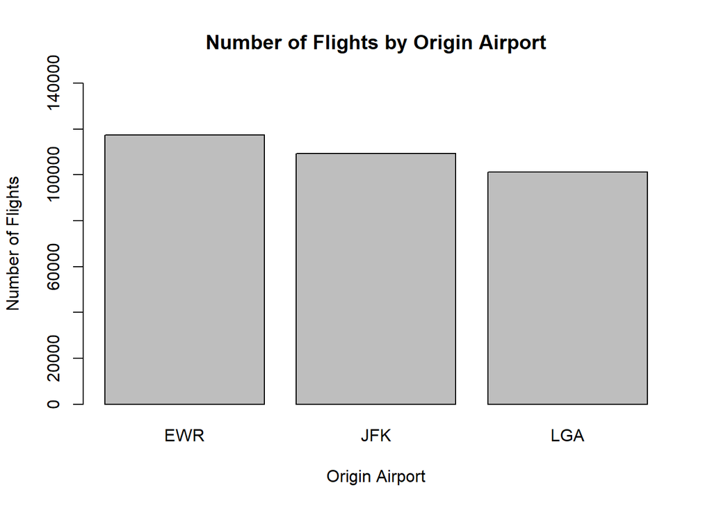

```r
# 5. Visualize the distributions of key variables
barplot(table(Merged_Flights_Weather$origin), main = "Number of Flights by Origin Airport", xlab = "Origin Airport", ylab = "Number of Flights", ylim = c(0, 140000))
```

```r
mean(is.na(Merged_Flights_Weather$origin))
```

```
[1] 0
```

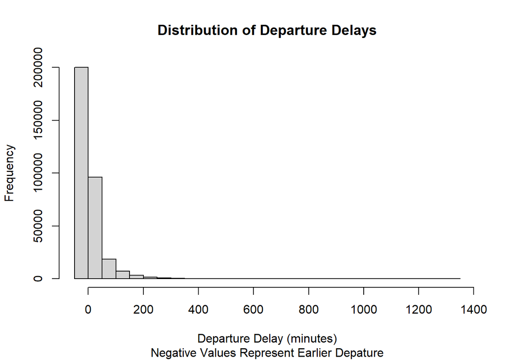

```r
hist(Merged_Flights_Weather$dep_delay, main = "Distribution of Departure Delays", xlab = "Departure Delay (minutes)", sub = "Negative Values Represent Earlier Depature")
```

```r
summary(Merged_Flights_Weather$dep_delay)
```

```
   Min. 1st Qu.  Median    Mean 3rd Qu.    Max.
 -43.00   -5.00   -2.00   12.58   11.00 1301.00
```

```r
mean(is.na(Merged_Flights_Weather$dep_delay))
```

```
[1] 0
```

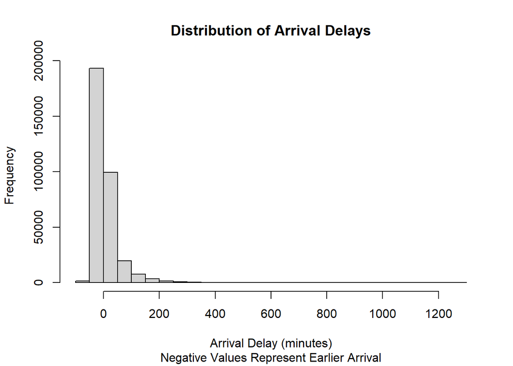

```r
hist(Merged_Flights_Weather$arr_delay, main = "Distribution of Arrival Delays", xlab = "Arrival Delay (minutes)", sub = "Negative Values Represent Earlier Arrival")
```

```r
summary(Merged_Flights_Weather$arr_delay)
```

```
    Min.  1st Qu.   Median     Mean  3rd Qu.     Max.      NAs
 -86.000  -17.000   -5.000    6.895   14.000 1272.000      717
```

```r
mean(is.na(Merged_Flights_Weather$arr_delay))
```

```
[1] 0.002185556
```

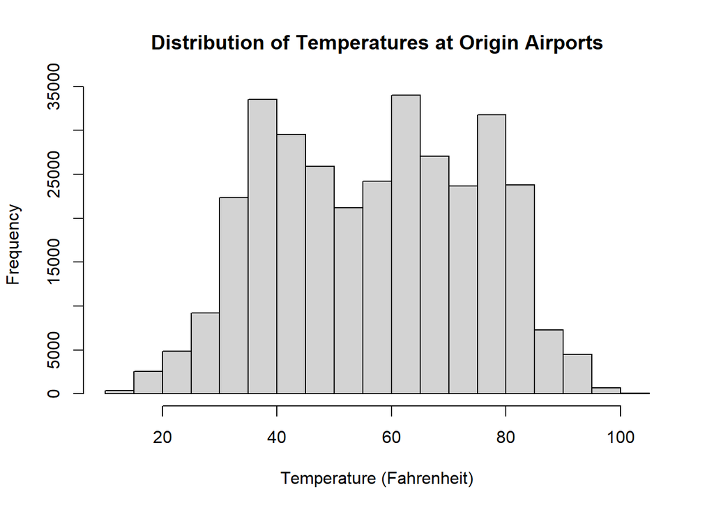

```r
hist(Merged_Flights_Weather$temp, main = "Distribution of Temperatures at Origin Airports", xlab = "Temperature (Fahrenheit)")
```

```r
summary(Merged_Flights_Weather$temp)
```

```
   Min. 1st Qu.  Median    Mean 3rd Qu.    Max.     NAs
  10.94   42.08   57.20   57.02   71.96  100.04    1545
```

```r
mean(is.na(Merged_Flights_Weather$temp))
```

```
[1] 0.004709461
```

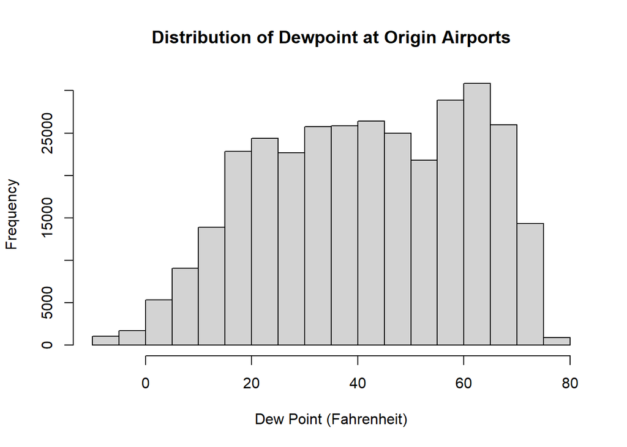

```r
hist(Merged_Flights_Weather$dewp, main = "Distribution of Dewpoint at Origin Airports", xlab = "Dew Point (Fahrenheit)")
```

```r
summary(Merged_Flights_Weather$dewp)
```

```
   Min. 1st Qu.  Median    Mean 3rd Qu.    Max.     NAs
  -9.94   26.06   42.80   41.51   57.92   78.08    1545
```

```r
mean(is.na(Merged_Flights_Weather$dewp))
```

```
[1] 0.004709461
```

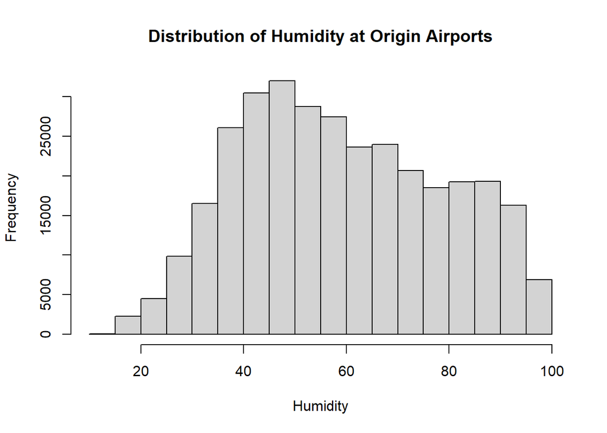

```r
hist(Merged_Flights_Weather$humid, main = "Distribution of Humidity at Origin Airports", xlab =
"Humidity")
```

```r
summary(Merged_Flights_Weather$humid)
```

```
   Min. 1st Qu.  Median    Mean 3rd Qu.    Max.     NAs
  12.74   43.74   57.22   59.22   74.67  100.00    1545
```

```r
mean(is.na(Merged_Flights_Weather$humid))
```

```
[1] 0.004709461
```

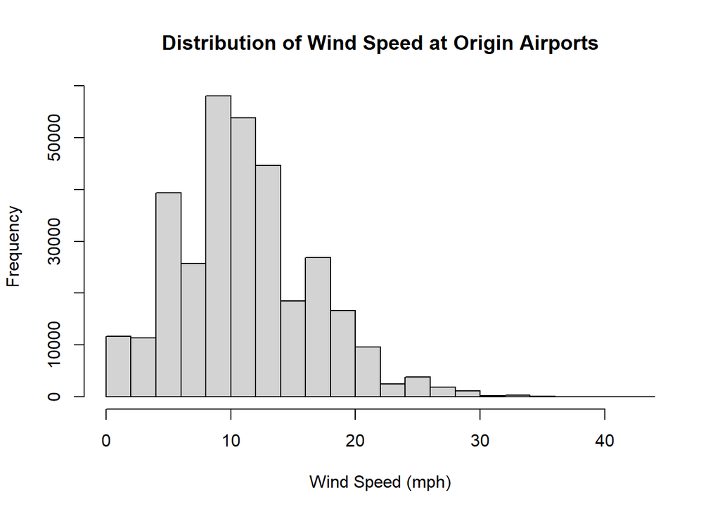

```r
hist(Merged_Flights_Weather$wind_speed, main = "Distribution of Wind Speed at Origin Airports", xlab = "Wind Speed (mph)")
```

```r
summary(Merged_Flights_Weather$wind_speed)
```

```
   Min. 1st Qu.  Median    Mean 3rd Qu.    Max.     NAs
  0.000   6.905  10.357  11.061  14.960  42.579    1606
```

```r
mean(is.na(Merged_Flights_Weather$wind_speed))
```

```
[1] 0.004895401
```

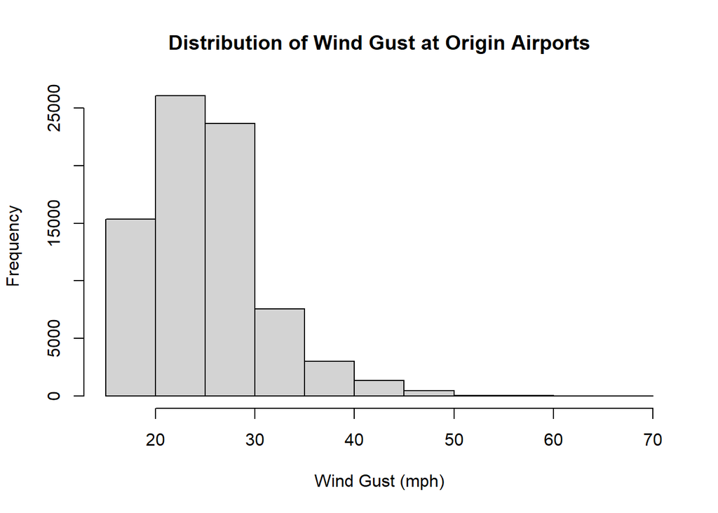

```r
hist(Merged_Flights_Weather$wind_gust, main = "Distribution of Wind Gust at Origin Airports", xlab = "Wind Gust (mph)")
```

```r
summary(Merged_Flights_Weather$wind_gust)
```

```
   Min. 1st Qu.  Median    Mean 3rd Qu.    Max.     NAs
  16.11   20.71   24.17   25.15   27.62   66.75  250461
```

```r
mean(is.na(Merged_Flights_Weather$wind_gust))
```

```
[1] 0.763454
```

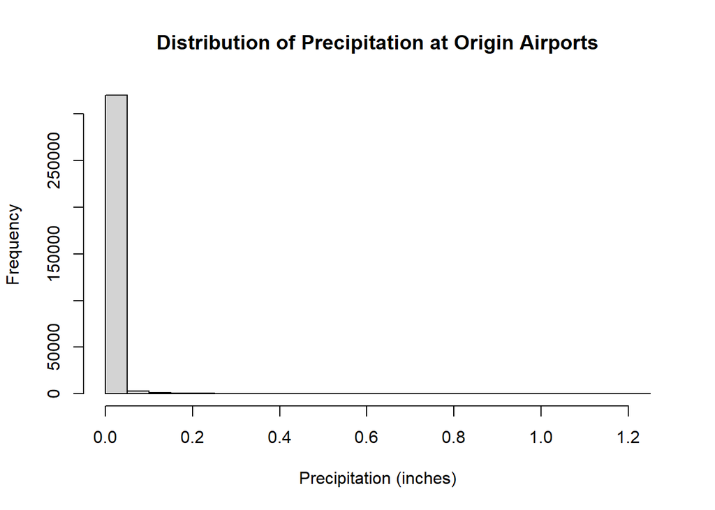

```r
hist(Merged_Flights_Weather$precip, main = "Distribution of Precipitation at Origin Airports", xlab = "Precipitation (inches)")
```

```r
summary(Merged_Flights_Weather$precip)
```

```
    Min.  1st Qu.   Median     Mean  3rd Qu.     Max.      NAs
0.000000 0.000000 0.000000 0.004225 0.000000 1.210000     1528
```

```r
mean(is.na(Merged_Flights_Weather$precip))
```

```
[1] 0.004657642
```

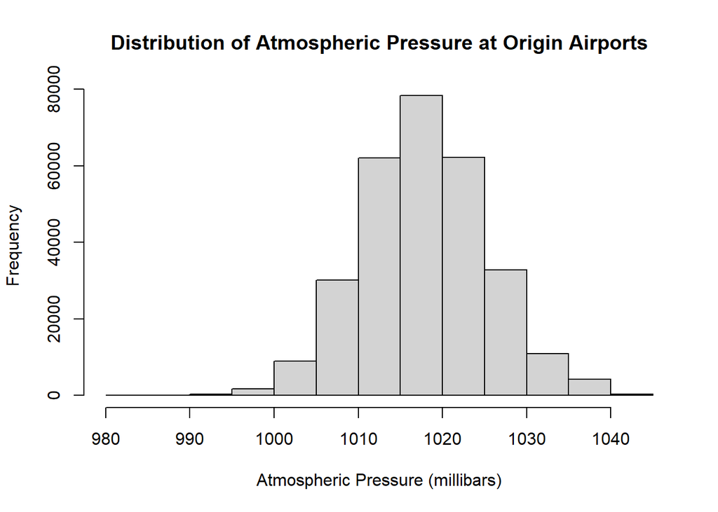

```r
hist(Merged_Flights_Weather$pressure, main = "Distribution of Atmospheric Pressure at Origin Airports", xlab = "Atmospheric Pressure (millibars)")
```

```r
summary(Merged_Flights_Weather$pressure)
```

```
   Min. 1st Qu.  Median    Mean 3rd Qu.    Max.     NAs
  983.8  1012.9  1017.6  1017.9  1022.9  1042.1   36224
```

```r
mean(is.na(Merged_Flights_Weather$pressure))
```

```
[1] 0.1104178
```

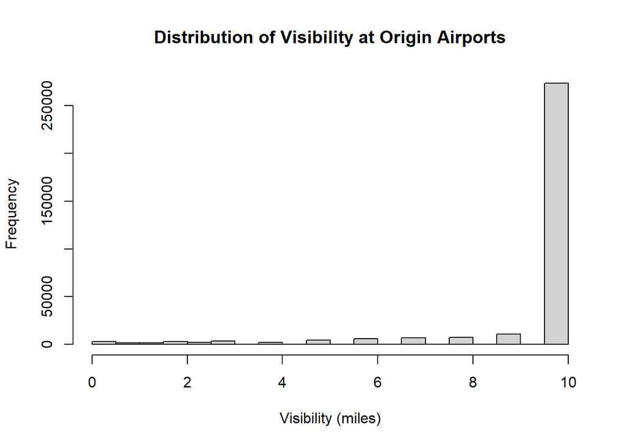

```r
hist(Merged_Flights_Weather$visib, main = "Distribution of Visibility at Origin Airports", xlab = "Visibility (miles)")
```

```r
summary(Merged_Flights_Weather$visib)
```

```
   Min. 1st Qu.  Median    Mean 3rd Qu.    Max.     NAs
  0.000  10.000  10.000   9.289  10.000  10.000    1528
```

```r
mean(is.na(Merged_Flights_Weather$visib))
```

```
[1] 0.004657642
```

## Summary

There are 328,063 recordings (rows) and 32 variables (columns). The variables are mainly integer and numeric, but there is one logical variable and some character variables. In the context of the primary question, the key variables would be: dep_delay, temp, dewp, humid, wind_speed, wind_gust, precip, pressure, and visib. Measurement units were found using the data library for flights and weather data (https://nycflights13.tidyverse.org/reference/flights.html). The data was not cleaned in this step, so there are still some missing values.

# Question 7

## Part 1

Calculate the average departure delay for each day (Hint: think about which variables you need in order to do this!). Which day had the worst average length of delay for departures?

```r
Daily_Delay <- Merged_Flights_Weather |>
  group_by(year, month, day) |>
  summarize(Average_Departure_Delay = mean(dep_delay, na.rm = TRUE), Amount_of_Flights = n()) |>
  arrange(desc(Average_Departure_Delay))
```

```
`summarise()` has regrouped the output.
ℹ Summaries were computed grouped by year, month, and day.
ℹ Output is grouped by year and month.
ℹ Use `summarise(.groups = "drop_last")` to silence this message.
ℹ Use `summarise(.by = c(year, month, day))` for per-operation grouping
  (`?dplyr::dplyr_by`) instead.
```

```r
head(Daily_Delay)
```

```
# A tibble: 6 × 5
# Groups:   year, month [5]
   year month   day Average_Departure_Delay Amount_of_Flights
  <int> <int> <int>                   <dbl>             <int>
1  2013     3     8                    83.6               798
2  2013     7     1                    56.4               878
3  2013     9     2                    53.1               845
4  2013    12     5                    52.4               810
5  2013     7    10                    51.7               850
6  2013     5    23                    50.8               758
```

### Summary

March 8th, 2013 was the worst day, as it had an average departure delay of about 84 minutes.

## Part 2

Now calculate the averages by day and origin. Which airport had the worst single day for delays and when was it?

```r
Daily_Delay_Airport <- Merged_Flights_Weather |>
  group_by(year, month, day, origin) |>
  summarize (Average_Depatrue_Delay = mean(dep_delay, na.rm = TRUE), Amount_of_Flights = n()) |>
  arrange(desc(Average_Depatrue_Delay))
```

```
`summarise()` has regrouped the output.
ℹ Summaries were computed grouped by year, month, day, and origin.
ℹ Output is grouped by year, month, and day.
ℹ Use `summarise(.groups = "drop_last")` to silence this message.
ℹ Use `summarise(.by = c(year, month, day, origin))` for per-operation grouping
  (`?dplyr::dplyr_by`) instead.
```

```r
head(Daily_Delay_Airport)
```

```
# A tibble: 6 × 6
# Groups:   year, month, day [4]
   year month   day origin Average_Depatrue_Delay Amount_of_Flights
  <int> <int> <int> <chr>                   <dbl>             <int>
1  2013     3     8 LGA                     106.                228
2  2013     3     8 EWR                      97.8               266
3  2013     9     2 LGA                      80.5               246
4  2013    12     5 LGA                      75.2               240
5  2013     7     1 LGA                      62.9               265
6  2013    12     5 EWR                      61.2               293
```

### Summary

LGA had the single worst day for delays on March 8th, 2013, with an average departure delay of about 106 minutes.

## Part 3

Now calculate the averages by hour and origin. Which airport had the worst single hour for delays (and when was it)?

```r
Hourly_Delay_Airport <- Merged_Flights_Weather |>
  group_by(time_hour, origin) |>
  summarize(Average_Depature_Delay = mean(dep_delay, na.rm = TRUE), Amount_of_Flights = n()) |>
  arrange(desc(Average_Depature_Delay))
```

```
`summarise()` has regrouped the output.
ℹ Summaries were computed grouped by time_hour and origin.
ℹ Output is grouped by time_hour.
ℹ Use `summarise(.groups = "drop_last")` to silence this message.
ℹ Use `summarise(.by = c(time_hour, origin))` for per-operation grouping
  (`?dplyr::dplyr_by`) instead.
```

```r
head(Hourly_Delay_Airport)
```

```
# A tibble: 6 × 4
# Groups:   time_hour [6]
  time_hour           origin Average_Depature_Delay Amount_of_Flights
  <dttm>              <chr>                   <dbl>             <int>
1 2013-07-22 18:00:00 LGA                      310.                 4
2 2013-07-28 21:00:00 LGA                      280.                 3
3 2013-02-09 10:00:00 EWR                      269                  1
4 2013-02-09 09:00:00 EWR                      266                  1
5 2013-09-02 16:00:00 LGA                      250.                13
6 2013-07-28 19:00:00 LGA                      240.                14
```

### Summary

LGA had the worst single hour for delays on July 22nd, 2013 at 6 PM, with an average departure delay of about 310 minutes.

# Question 8

Compute the average arrival delay by destination, then add that information to the airports data frame. Make a map showing the spatial distribution of delays (you can make it however you like, but we recommend using either ggplot or leaflet). Use the color of the points to display the average delay for each airport.

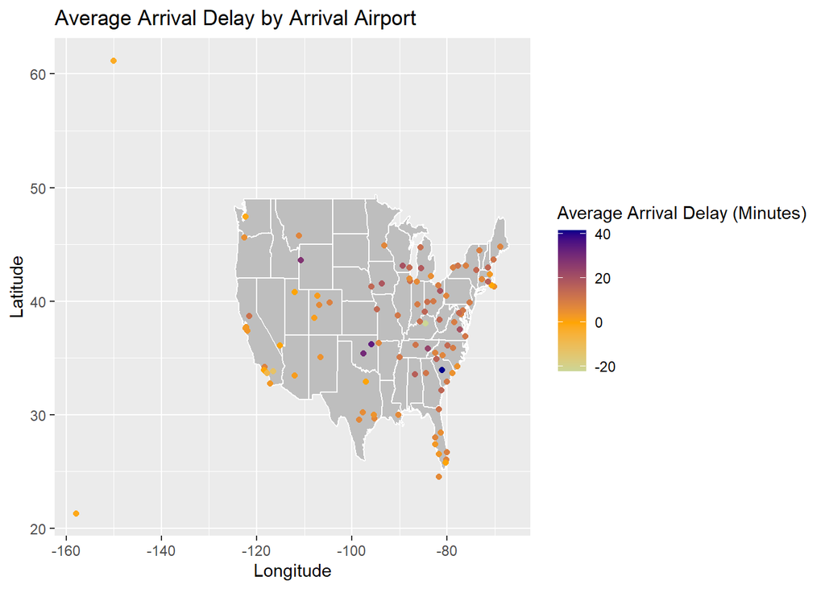

```r
Arrival_Delay <- Merged_Flights_Weather |>
  group_by(dest) |>
  summarize(Average_Arrival_Delay = mean(arr_delay, na.rm = TRUE), Amount_of_Flights = sum(!is.na(arr_delay))) |>
  filter(Amount_of_Flights > 0)

airports <- airports |>
  left_join(Arrival_Delay, by = c("faa" = "dest"))

airports <- airports |>
  filter(!is.na(Average_Arrival_Delay))

US_Map <- map_data("state")
ggplot() +
  geom_polygon(data = US_Map, aes(x = long, y = lat, group = group), fill = "gray", color = "white") +
  geom_point(data=airports,  aes(x = lon, y = lat, color = Average_Arrival_Delay)) +
  scale_color_gradient2(low = "cyan", mid = "orange", high = "darkblue", name = "Average Arrival Delay (Minutes)") +
  labs(title = "Average Arrival Delay by Arrival Airport", x = "Longitude", y = "Latitude")
```

# Question 9

Finally, create as many plots and summary statistics as needed to answer the primary question: Which weather phenomena have the most impact on flight delays?

```r
Weather_Variables <- c("dep_delay", "temp", "humid", "dewp", "wind_speed", "wind_gust", "precip", "pressure", "visib")

Weather_Delay <- Merged_Flights_Weather
Weather_Delay$Visibility_Category <- ifelse(is.na(Weather_Delay$visib), NA, ifelse(Weather_Delay$visib < 3, "Low Visibility", "High Visibility"))
Weather_Delay$Precipitation_Category <- ifelse(is.na(Weather_Delay$precip), NA, ifelse(Weather_Delay$precip > 0, "Precipitation", "No Precipitation"))
Weather_Delay$WindSpeed_Category <- ifelse(is.na(Weather_Delay$wind_speed), NA, ifelse(Weather_Delay$wind_speed >= 30, "High Wind", "Low Wind"))
Weather_Delay$WindGust_Category <- ifelse(is.na(Weather_Delay$wind_gust), NA, ifelse(Weather_Delay$wind_gust >= 30, "High Gust", "Low Gust"))
Weather_Delay$Pressure_Category <- ifelse(is.na(Weather_Delay$pressure), NA, ifelse(Weather_Delay$pressure >= 1015.92, "High Pressure", "Low Pressure"))
Weather_Delay$Dewpoint_Category <- ifelse(is.na(Weather_Delay$dewp), NA, ifelse(Weather_Delay$dewp >= 65, "High Dew Point", "Low Dew Point"))
Weather_Delay$Temperature_Category <- ifelse(is.na(Weather_Delay$temp), NA, ifelse(Weather_Delay$temp >= 32, "Not Freezing", "Freezing"))
Weather_Delay$Humidity_Category <- ifelse(is.na(Weather_Delay$humid), NA, ifelse(Weather_Delay$humid >= 70, "High Humidity", "Low Humidity"))

Correlations <- cor(Weather_Delay[Weather_Variables], use = "pairwise.complete.obs", method = "spearman")

Departure_Delay_Correlation <- Correlations[rownames(Correlations) != "dep_delay", "dep_delay"]
Departure_Delay_Correlation <- Departure_Delay_Correlation[order(Departure_Delay_Correlation, decreasing = TRUE)]
Departure_Delay_Correlation
```

```
     precip       humid        dewp  wind_speed        temp   wind_gust
 0.11625512  0.09362466  0.08577872  0.06306282  0.04857837  0.03716653
      visib    pressure
-0.08294774 -0.10930886
```

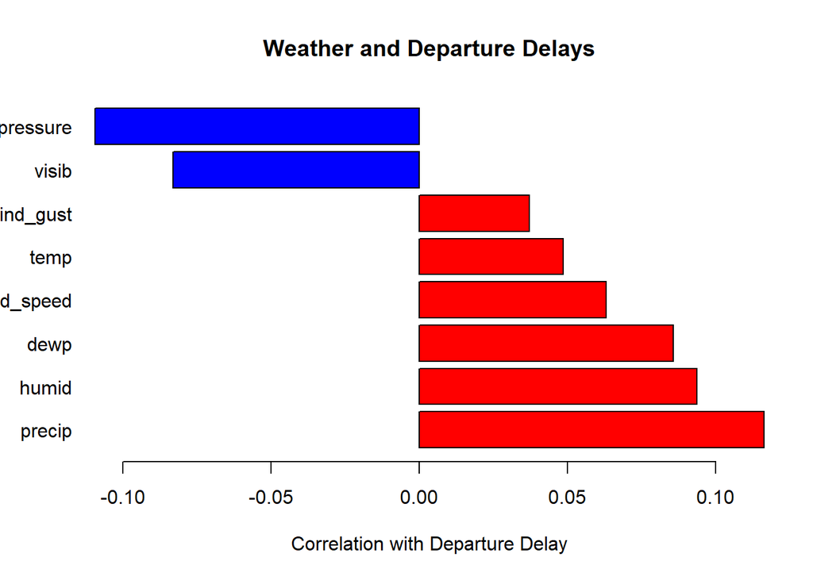

```r
barplot(Departure_Delay_Correlation, horiz = TRUE, las = 1, col = ifelse(Departure_Delay_Correlation >0, "red", "blue"), xlab = "Correlation with Departure Delay", main = "Weather and Departure Delays")
```

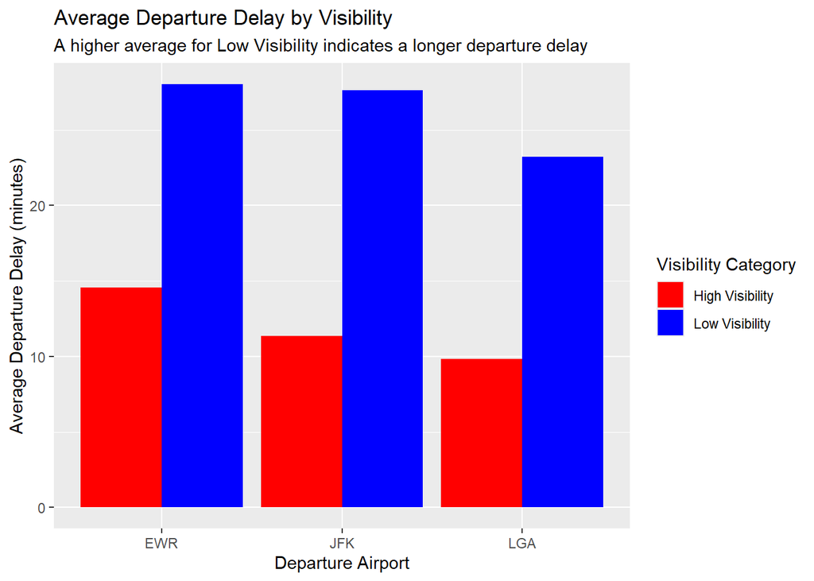

```r
Visibility_Delay <- Weather_Delay |>
  filter(!is.na(Visibility_Category),!is.na(dep_delay)) |>
  group_by(origin, Visibility_Category) |>
  summarize(Departure_Delay_Mean = mean(dep_delay), Number_of_Flights = n(),.groups = "drop")

ggplot(Visibility_Delay,aes(x = origin, y = Departure_Delay_Mean,fill = Visibility_Category)) +
  geom_col(position = "dodge") +
  scale_fill_manual(values = c("High Visibility" = "red", "Low Visibility" = "blue")) +
  labs(title = "Average Departure Delay by Visibility", x = "Departure Airport", y = "Average Departure Delay (minutes)", subtitle = "A higher average for Low Visibility indicates a longer departure delay", fill = "Visibility Category")
```

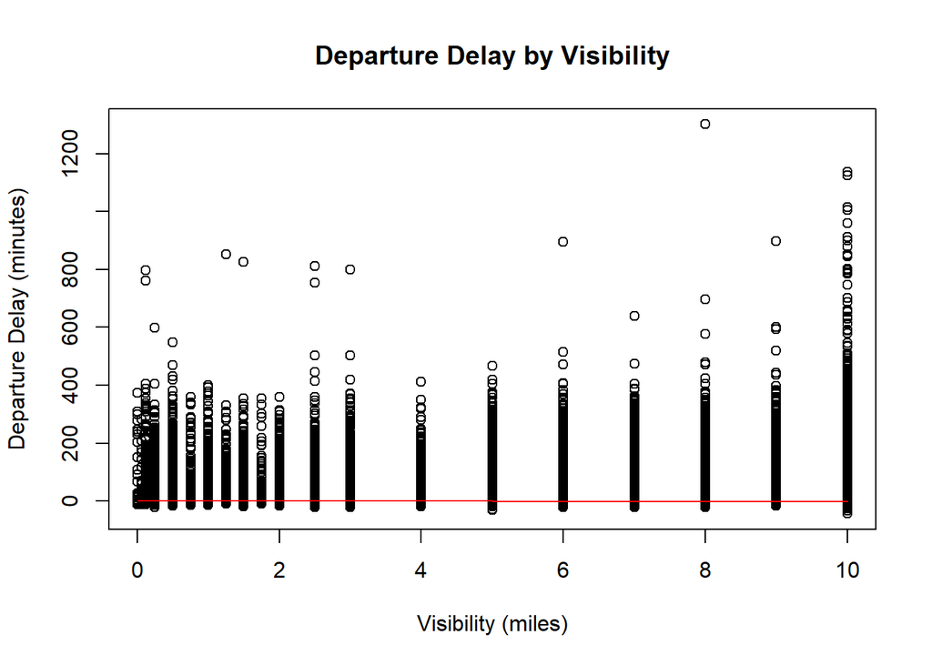

```r
complete_rows <- complete.cases(Weather_Delay$visib, Weather_Delay$dep_delay)
plot(Weather_Delay$visib, Weather_Delay$dep_delay, xlab = "Visibility (miles)", ylab = "Departure Delay (minutes)", main = "Departure Delay by Visibility", xlim = c(0,10))
lines(lowess(Weather_Delay$visib[complete_rows], Weather_Delay$dep_delay[complete_rows]), col = "red")
```

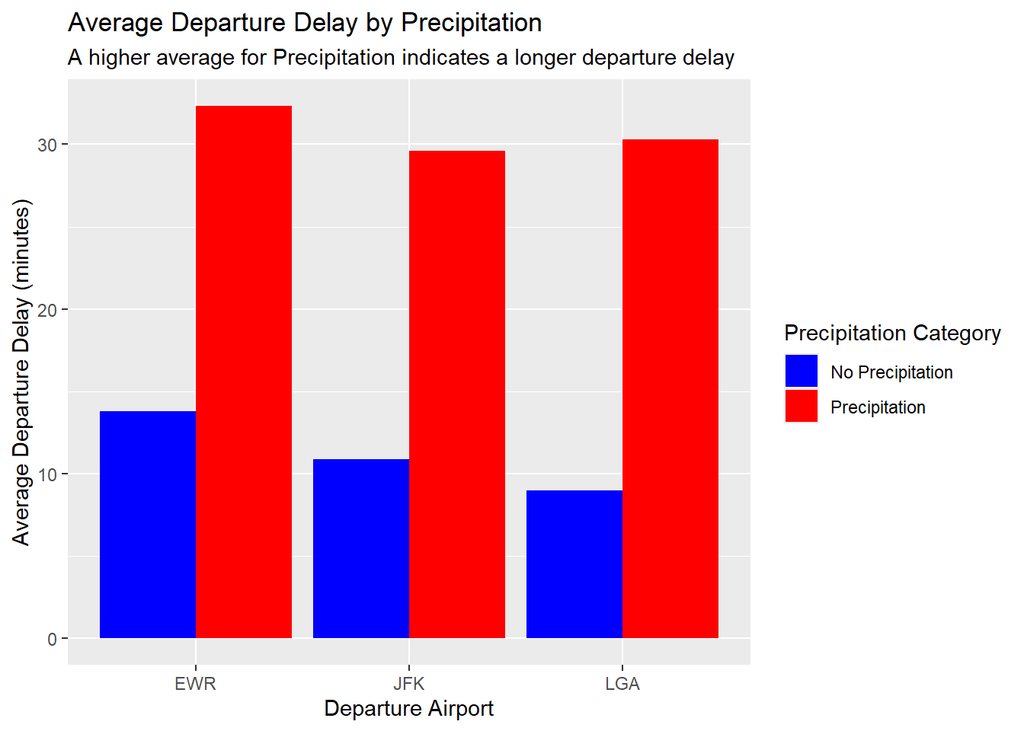

```r
Precipitation_Delay <- Weather_Delay |>
  filter(!is.na(Precipitation_Category),!is.na(dep_delay)) |>
  group_by(origin, Precipitation_Category) |>
  summarize(Departure_Delay_Mean = mean(dep_delay), Number_of_Flights = n(),.groups = "drop")

ggplot(Precipitation_Delay,aes(x = origin, y = Departure_Delay_Mean,fill = Precipitation_Category)) +
  geom_col(position = "dodge") +
  scale_fill_manual(values = c( "No Precipitation" = "blue", "Precipitation" = "red")) +
  labs(title = "Average Departure Delay by Precipitation", x = "Departure Airport", y = "Average Departure Delay (minutes)", subtitle = "A higher average for Precipitation indicates a longer departure delay", fill = "Precipitation Category")
```

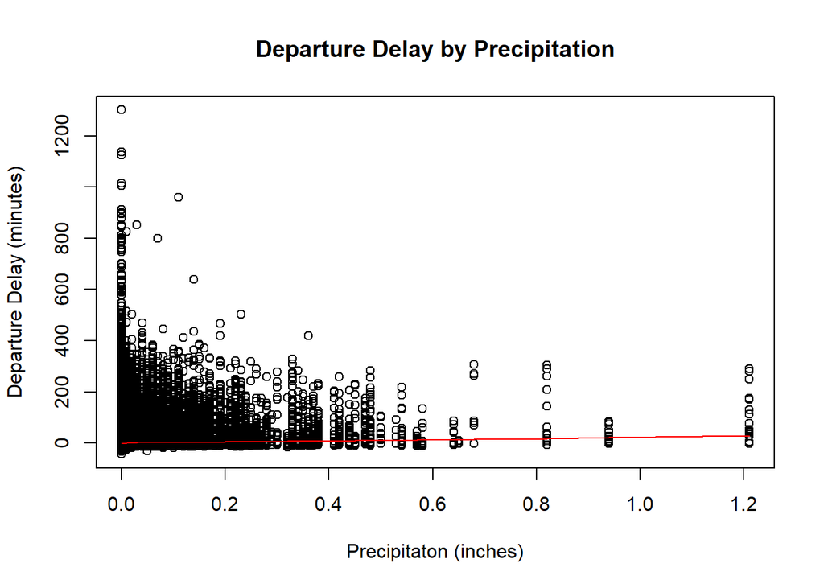

```r
complete_rows <- complete.cases(Weather_Delay$precip, Weather_Delay$dep_delay)
plot(Weather_Delay$precip, Weather_Delay$dep_delay, xlab = "Precipitaton (inches)", ylab = "Departure Delay (minutes)", main = "Departure Delay by Precipitation")
lines(lowess(Weather_Delay$precip[complete_rows], Weather_Delay$dep_delay[complete_rows]), col = "red")
```

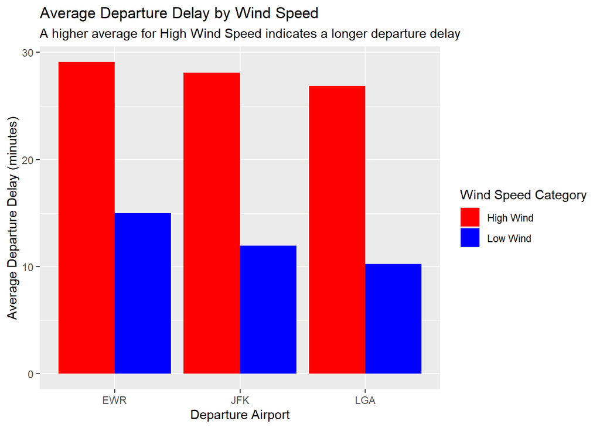

```r
WindSpeed_Delay <- Weather_Delay |>
  filter(!is.na(WindSpeed_Category),!is.na(dep_delay)) |>
  group_by(origin, WindSpeed_Category) |>
  summarize(Departure_Delay_Mean = mean(dep_delay), Number_of_Flights = n(),.groups = "drop")

ggplot(WindSpeed_Delay,aes(x = origin, y = Departure_Delay_Mean,fill = WindSpeed_Category)) +
  geom_col(position = "dodge") +
  scale_fill_manual(values = c("High Wind" = "red", "Low Wind" = "blue")) +
  labs(title = "Average Departure Delay by Wind Speed", x = "Departure Airport", y = "Average Departure Delay (minutes)", subtitle = "A higher average for High Wind Speed indicates a longer departure delay", fill = "Wind Speed Category")
```

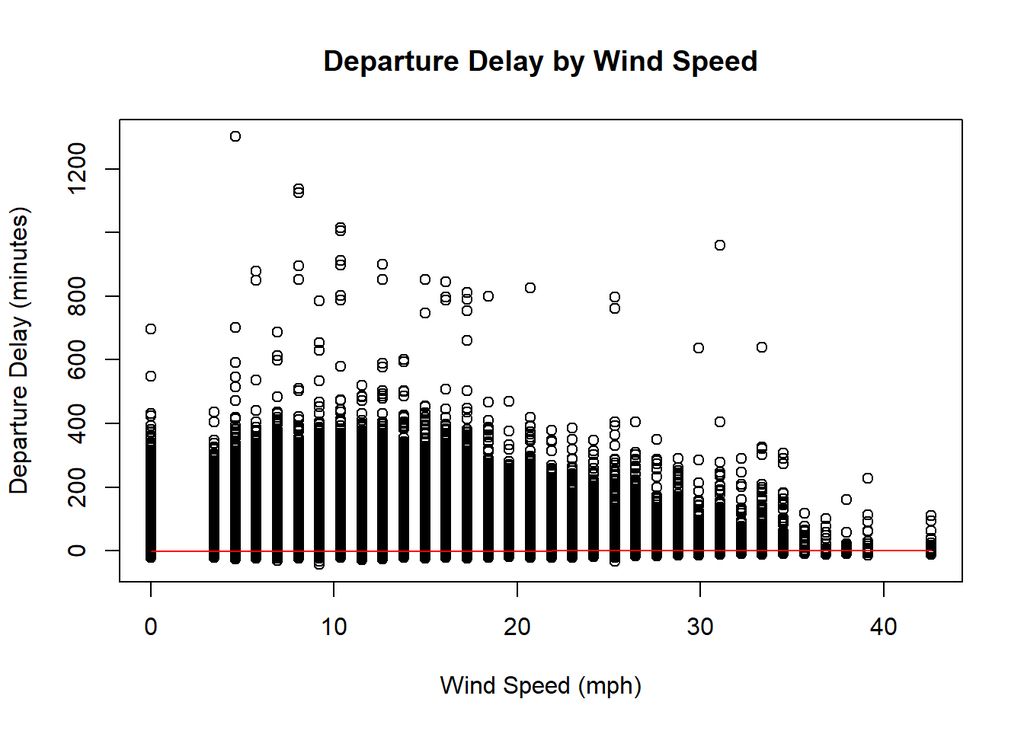

```r
complete_rows <- complete.cases(Weather_Delay$wind_speed, Weather_Delay$dep_delay)
plot(Weather_Delay$wind_speed, Weather_Delay$dep_delay, xlab = "Wind Speed (mph)", ylab = "Departure Delay (minutes)", main = "Departure Delay by Wind Speed")
lines(lowess(Weather_Delay$wind_speed[complete_rows], Weather_Delay$dep_delay[complete_rows]), col = "red")
```

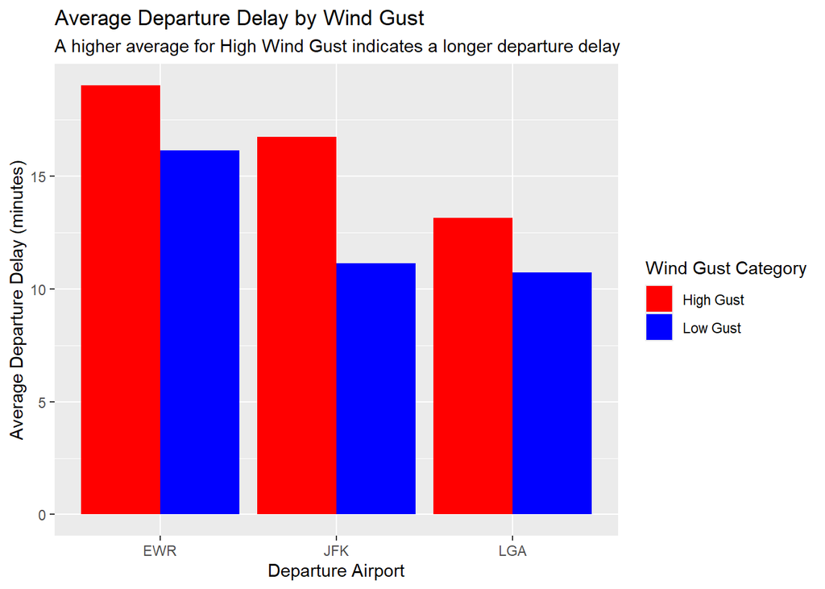

```r
WindGust_Delay <- Weather_Delay |>
  filter(!is.na(WindGust_Category),!is.na(dep_delay)) |>
  group_by(origin, WindGust_Category) |>
  summarize(Departure_Delay_Mean = mean(dep_delay), Number_of_Flights = n(),.groups = "drop")

ggplot(WindGust_Delay,aes(x = origin, y = Departure_Delay_Mean,fill = WindGust_Category)) +
  geom_col(position = "dodge") +
  scale_fill_manual(values = c("High Gust" = "red", "Low Gust" = "blue")) +
  labs(title = "Average Departure Delay by Wind Gust", x = "Departure Airport", y = "Average Departure Delay (minutes)", subtitle = "A higher average for High Wind Gust indicates a longer departure delay", fill = "Wind Gust Category")
```

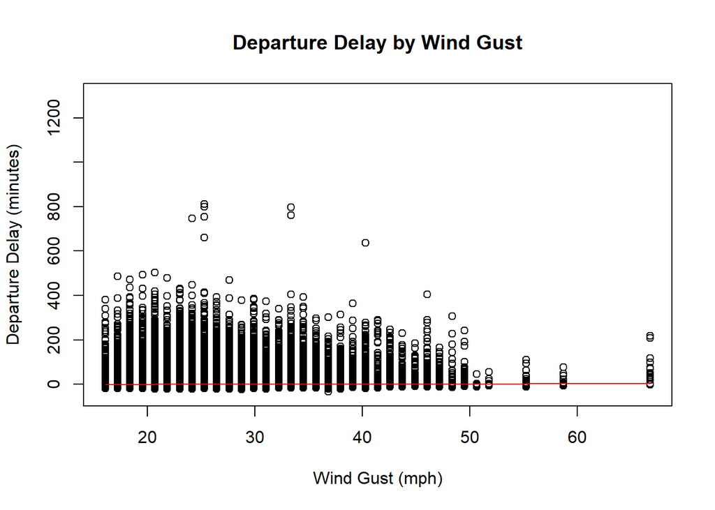

```r
complete_rows <- complete.cases(Weather_Delay$wind_gust, Weather_Delay$dep_delay)
plot(Weather_Delay$wind_gust, Weather_Delay$dep_delay, xlab = "Wind Gust (mph)", ylab = "Departure Delay (minutes)", main = "Departure Delay by Wind Gust")
lines(lowess(Weather_Delay$wind_gust[complete_rows], Weather_Delay$dep_delay[complete_rows]), col = "red")
```

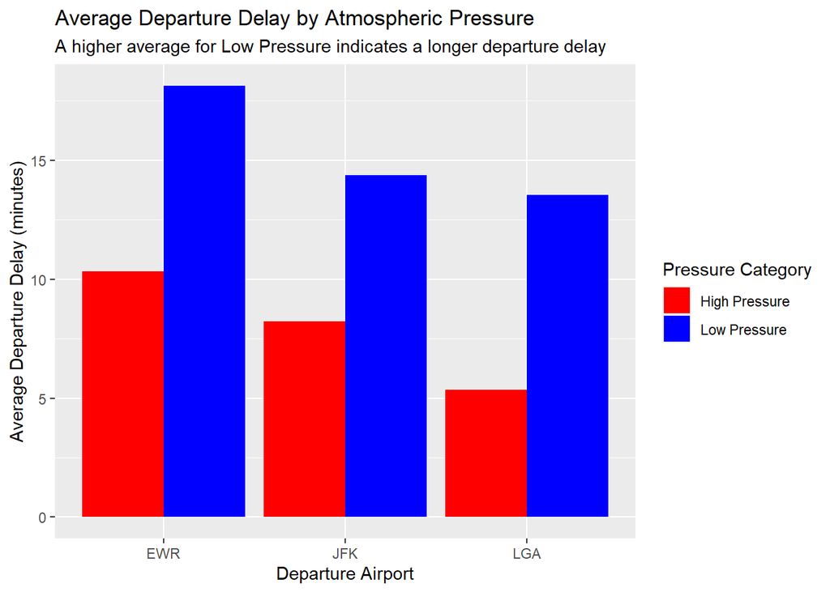

```r
Pressure_Delay <- Weather_Delay |>
  filter(!is.na(Pressure_Category),!is.na(dep_delay)) |>
  group_by(origin, Pressure_Category) |>
  summarize(Departure_Delay_Mean = mean(dep_delay), Number_of_Flights = n(),.groups = "drop")

ggplot(Pressure_Delay,aes(x = origin, y = Departure_Delay_Mean,fill = Pressure_Category)) +
  geom_col(position = "dodge") +
  scale_fill_manual(values = c("High Pressure" = "red", "Low Pressure" = "blue")) +
  labs(title = "Average Departure Delay by Atmospheric Pressure", x = "Departure Airport", y = "Average Departure Delay (minutes)", subtitle = "A higher average for Low Pressure indicates a longer departure delay", fill = "Pressure Category")
```

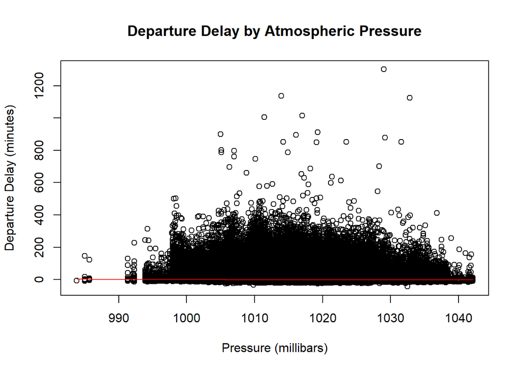

```r
complete_rows <- complete.cases(Weather_Delay$pressure, Weather_Delay$dep_delay)
plot(Weather_Delay$pressure, Weather_Delay$dep_delay, xlab = "Pressure (millibars)", ylab = "Departure Delay (minutes)", main = "Departure Delay by Atmospheric Pressure")
lines(lowess(Weather_Delay$pressure[complete_rows], Weather_Delay$dep_delay[complete_rows]), col = "red")
```

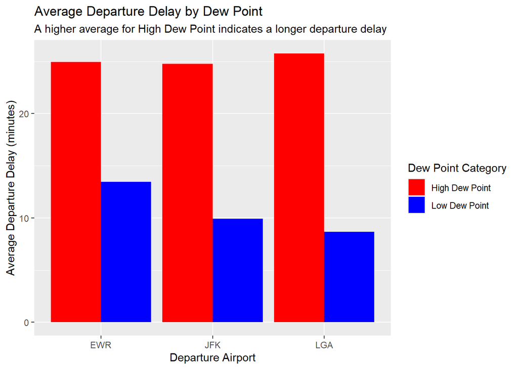

```r
Dewp_Delay <- Weather_Delay |>
  filter(!is.na(Dewpoint_Category),!is.na(dep_delay)) |>
  group_by(origin, Dewpoint_Category) |>
  summarize(Departure_Delay_Mean = mean(dep_delay), Number_of_Flights = n(),.groups = "drop")

ggplot(Dewp_Delay,aes(x = origin, y = Departure_Delay_Mean,fill = Dewpoint_Category)) +
  geom_col(position = "dodge") +
  scale_fill_manual(values = c("High Dew Point" = "red", "Low Dew Point" = "blue")) +
  labs(title = "Average Departure Delay by Dew Point", x = "Departure Airport", y = "Average Departure Delay (minutes)", subtitle = "A higher average for High Dew Point indicates a longer departure delay", fill = "Dew Point Category")
```

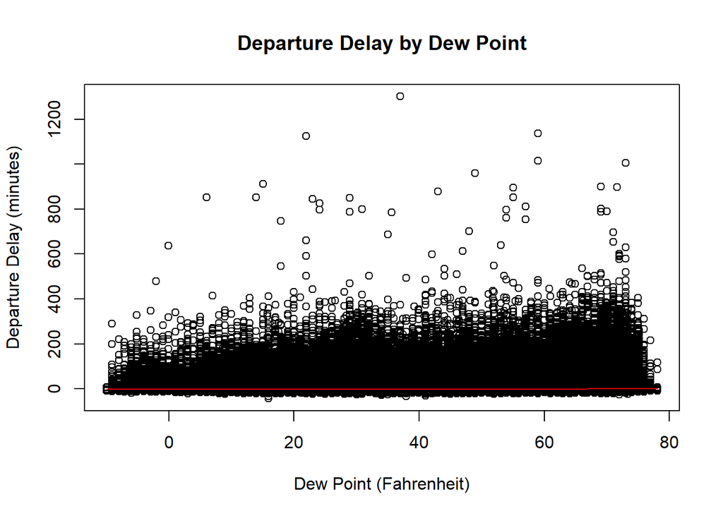

```r
complete_rows <- complete.cases(Weather_Delay$pressure, Weather_Delay$dep_delay)
plot(Weather_Delay$dewp, Weather_Delay$dep_delay, xlab = "Dew Point (Fahrenheit)", ylab = "Departure Delay (minutes)", main = "Departure Delay by Dew Point")
lines(lowess(Weather_Delay$dewp[complete_rows], Weather_Delay$dep_delay[complete_rows]), col = "red")
```

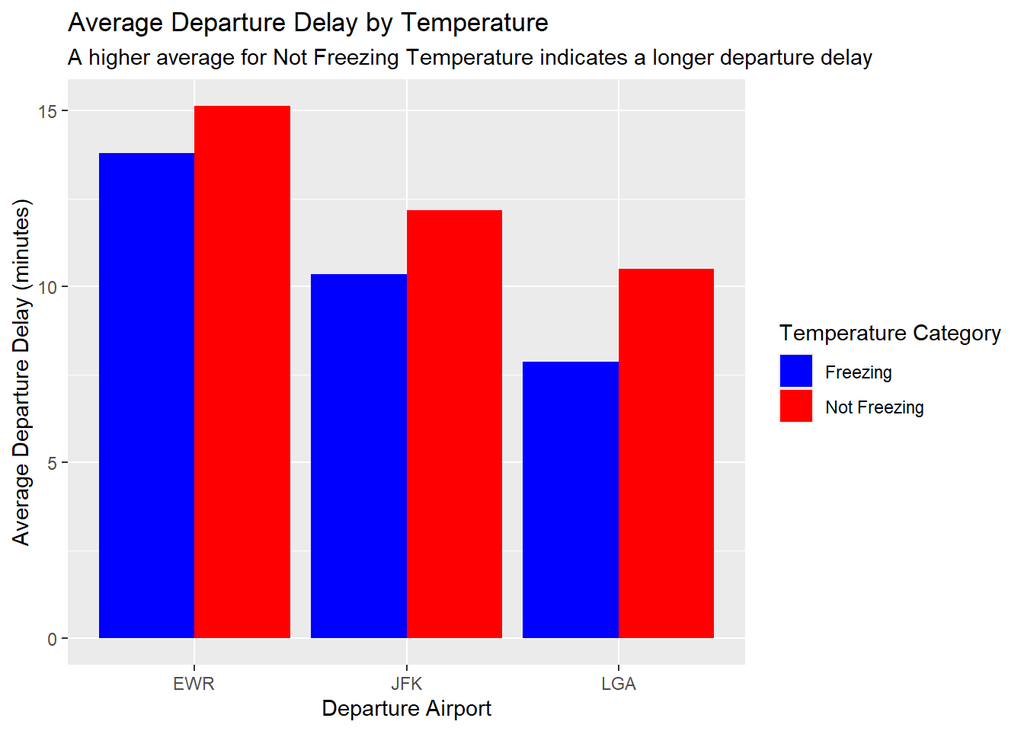

```r
Temp_Delay <- Weather_Delay |>
  filter(!is.na(Temperature_Category),!is.na(dep_delay)) |>
  group_by(origin, Temperature_Category) |>
  summarize(Departure_Delay_Mean = mean(dep_delay), Number_of_Flights = n(),.groups = "drop")

ggplot(Temp_Delay,aes(x = origin, y = Departure_Delay_Mean,fill = Temperature_Category)) +
  geom_col(position = "dodge") +
  scale_fill_manual(values = c("Not Freezing" = "red", "Freezing" = "blue")) +
  labs(title = "Average Departure Delay by Temperature", x = "Departure Airport", y = "Average Departure Delay (minutes)", subtitle = "A higher average for Not Freezing Temperature indicates a longer departure delay", fill = "Temperature Category")
```

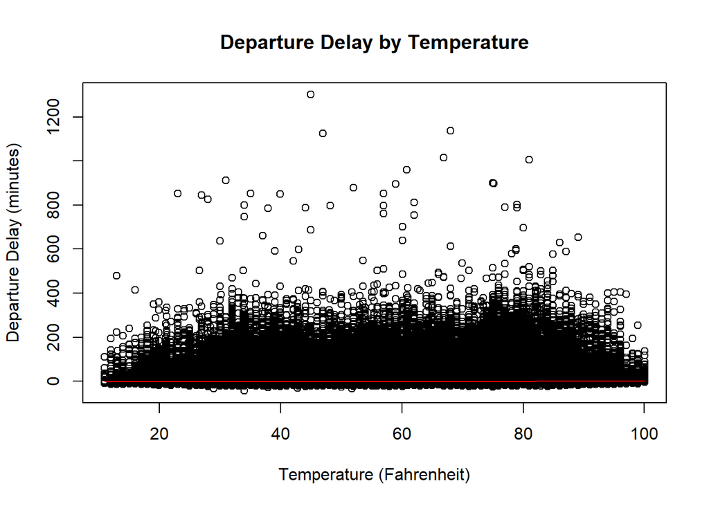

```r
complete_rows <- complete.cases(Weather_Delay$pressure, Weather_Delay$dep_delay)
plot(Weather_Delay$temp, Weather_Delay$dep_delay, xlab = "Temperature (Fahrenheit)", ylab = "Departure Delay (minutes)", main = "Departure Delay by Temperature")
lines(lowess(Weather_Delay$temp[complete_rows], Weather_Delay$dep_delay[complete_rows]), col = "red")
```

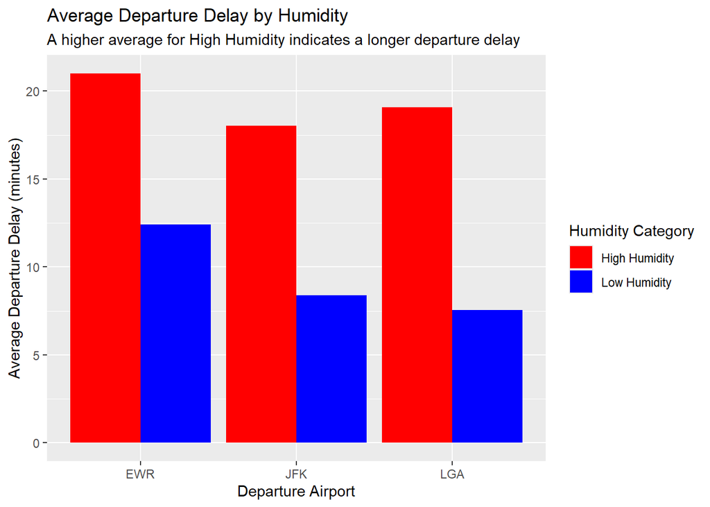

```r
Humid_Delay <- Weather_Delay |>
  filter(!is.na(Humidity_Category),!is.na(dep_delay)) |>
  group_by(origin, Humidity_Category) |>
  summarize(Departure_Delay_Mean = mean(dep_delay), Number_of_Flights = n(),.groups = "drop")

ggplot(Humid_Delay,aes(x = origin, y = Departure_Delay_Mean,fill = Humidity_Category)) +
  geom_col(position = "dodge") +
  scale_fill_manual(values = c("High Humidity" = "red", "Low Humidity" = "blue")) +
  labs(title = "Average Departure Delay by Humidity", x = "Departure Airport", y = "Average Departure Delay (minutes)", subtitle = "A higher average for High Humidity indicates a longer departure delay", fill = "Humidity Category")
```

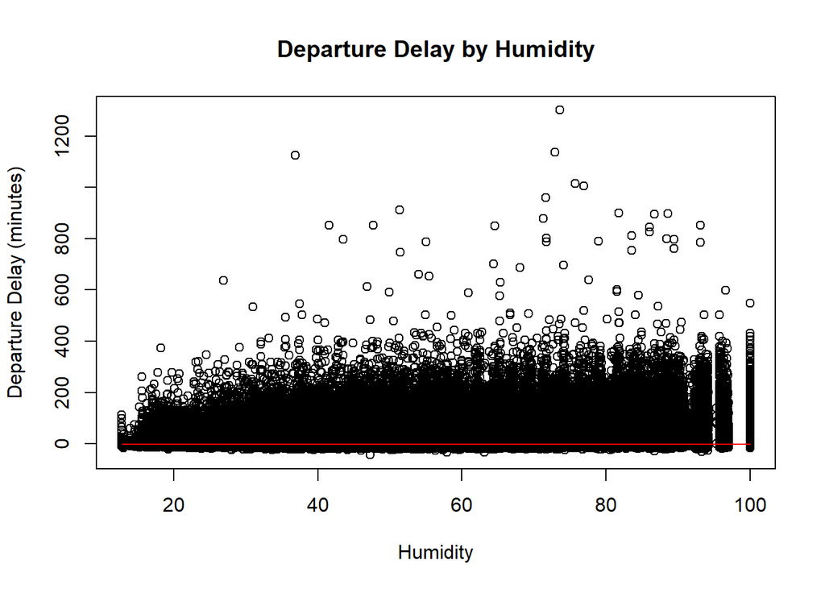

```r
complete_rows <- complete.cases(Weather_Delay$pressure, Weather_Delay$dep_delay)
plot(Weather_Delay$humid, Weather_Delay$dep_delay, xlab = "Humidity", ylab = "Departure Delay (minutes)", main = "Departure Delay by Humidity")
lines(lowess(Weather_Delay$humid[complete_rows], Weather_Delay$dep_delay[complete_rows]), col = "red")
```